# Research Proposal

### Investigating the relationship between control abundances and effect sizes

The varation in effect sizes is models by the scale parameter of a Cauchy distribution. The scale parameter is defined as a quadratic functions of the control abundances, shown in equation by $\ref{eq1}$.
$$\begin{align} \label{eq1}
y_i &= Cauchy(location = 0, scale = \gamma_i), \gamma_i = \exp(k_0
+ k_1x_i + k_2 {x_i}^2),
\end{align}$$
where $y_i$ and $x_i$ are the effect size and control abundance, respectively, for the $i^{th}$ taxa and $k_j ; j = 1, 2, 3$ are constants to be estimated.

### Conclusion

## Longitudinal Microbiome Data Analysis

### Literature Review and Background

#### Existing Models

#### Some existing packages

### Proposed research

### Challenges

### Simulation studies

### Conclusion

# Research Goals

The goal of this project is to

1. model the relationship between taxa abundances over time and covariate variables of interest (for instance, clinical and environmental factors such as age, groups or disease status of patients, among others), while accounting for the correlation structure between individual taxa within individual subjects. The unstructured correlation matrix, however, requires too many parameter estimates and is computationally infeasible for a typical ASV or OTU tables with thousands of taxa. Thus, a reduced rank latent variable model’s estimation of the structured correlation matrix will provide an understanding of the correlation between taxa on the community level.
2. model how microbiome abundances change over time between groups and determine taxa with differential abundances over time between groups.

# Methods

## Model Description:

The count data denoted by $Y_{ijt}$ is modeled by a negative binomial model defined as
$$\begin{align}
Y_{ijt} &\sim NB(mean = \mu_{ijt}, dispersion = \alpha_{it}),\\
\boldsymbol\mu &= g^{-1}(E) \nonumber \\
E &= X\beta + Zb,\,\,b \sim MVN(0, \Sigma) \nonumber
\end{align}$$
where $i,j$ and $t$ denote the $i^{th}$ taxa, $j^{th}$ sample and the $t^{th}$ time, respectively, and $Y_{i,j,t}$ denotes the count data for the $i^{th}$ taxa in the $j^{th}$ sample at time $t^{th}$. The function $g^{-1}$ is the link function and $\boldsymbol\mu$ is a vector of means with entries $\mu_{ijt}$. $X$ and $Z$ are the fixed and the random effect model matrices respectively and $\beta$ is the fixed effect parameter. The vector $b$ is a multivariate deviate from a gaussian distribution with a variance covariance matrix $\Sigma$.

# Background

## Introduction

Longitudinal data arises when repeated measures are collected for the same subject. For example; DNA taking the microbiome of pregnant women repeatedly over a multiple time points. The literature of longitudinal microbiome investigations has generally respond mainly to two queries: (1). to determine how microbiome abundances changes over time between groups (for example cases versus controls) (**lewis2015inflammation?**; **backhed2015dynamics?**), and 2. to investigate the relationship between microbiome abundances and other factors, for instance, environmental factors, clinical outcomes, etc) (**kodikara2022statistical?**; **chen2016two?**).

Analyzing longitudinal microbiome data is challenging. First, In addition to the special propertes of overdispersion of microbiome data due to the variations in read depth and zero inflation, repeated measurements exhibit correlation between observations taken from the same subject at various times points. Longitudinal data also often tend to have more missing data from a person or data not taken from everyone at all the time period studied (**kodikara2022statistical?**). For instance, a longitudinal study collecting faecal specimens from patients may have missing data due to patients dropping out of the study during the period of the specimen collection.

## Models used in the Literature

Over-Dispersion Models, Zero-Inflated and Zero-hurdle Models, Dirichlet-Multinomial Models, and Multivariate Bayesian Mixed-Effects Model and other Mixed Models have been commonly used in the literature for microbome analysis (**xia2018statistical?**). This section gives an overview of some of the common modeled fitted to microbiome data in the literature.

### Over-dispersion

Poisson and Negative Binomial distributions have been applied extensively for analyzing count data (**zhang2017negative?**). A limitation however of the poisson distributions is that it assumes the mean equals variance and does not account for overdispersion in microbiome data (**anders2010differential?**). Negative binomial models have been proposed to address the problem of overdispersion (**zhang2020nbzimm?**). (**zhang2017negative?**)

### Zero-inflation and Zero-hurdle Models

Zero-Inflated Models and Zero-hurdle Models have been applied to address the problem of sparsity in microbiome data (**xia2018statistical?** ; **zhang2020nbzimm?**). The hurdle model (also know as a two-part model), considers the data as comprising of zero and nonzero components and model the probability of obtaining a zero by a binomial distribution or a logistic regression model and the non-zero counts by a zero-truncated model such as a zero-truncated Poisson or zero-truncated negative binomial model. Zero inflation models (also known classified as a mixture model), on the other hand, considers the data as consisting of a count of components including rounded zeros and a second component for excess zeros. The excess zeros are modeled by the probability of expecting a zero under the considered distribution.

Examples of zero-inflated and zero-hurdle models used in the literature for count data include zero-inflated Poisson (ZIP) and the zero-inflated negative binomial models (ZINB), zero-hurdle Poisson (ZHP) and the zero-hurdle negative binomial models (ZHNB) (**xia2018statistical?**). The zero-inflated beta regression models have been used for proportion data (**xia2018statistical?**). Zero-inflated Gaussian models have also been proposed for modelling either count or proposition data (Kodikara et al., 2022, p. 7). (**paulson2013differential?**), for instance, developed a zero-inflated Gaussian model using the logtransformation on the read counts to address the problem of excessive zeros. An empirical Bayes method was used to estimate the moderated variances in the model. (**peng2016zero?**) and (**ospina2012general?**) also developed the zero-inflated beta regression model and the zero-or-one inflated beta regression model, respectively, for proportion data.

### Dirichlet-Multinomial Models

More recently developed model for the analysis of microbiome data are the multinomial and Dirichlet-Multinomial Models (**xia2018statistical?**; **holmes2012dirichlet?**). The multinomial and Dirichlet-multinomial distributions are the commonly used parametric probability models (**la2012hypothesis?**; **holmes2012dirichlet?**). (**holmes2012dirichlet?**) developed a Dirichlet multinomial mixtures model for classification and clustering otus of microbiome samples. A reparameterized Dirichlet multinomial model was developed by (**la2012hypothesis?**) to test the hypothesis of mean abundances as well as scales (variance comparison/dispersion) between groups. This model is implemented in the **HMP** package in R.

### Multivariate Bayesian Mixed-Effects Model

*Multivariate Bayesian Mixed-Effects Model. Grantham et al. 2019 propose a Bayesian mixedeffects model to analyze microbiome data.*

*MIMIX performs spike-and-slab variable selection to identify treatment effects on OTUs. Bayesian factor analysis with a Dirichlet-Laplace prior clusters OTUs into different factors. MIMIX is not currently suited for handling data from longitudinal studies*

### Models for longitudinal data analysis

Mixed models have been used for modeling longitudinal data in the literature.

#### Zero-inflated beta regression Model

To test the relationship between microbial abundance and clinical covariates in longitudinal microbiome data, (**chen2016two?**) developed a two-part zero-inflated Beta regression model with random effects (ZIBR). The model consists of a logistic regression component to model the presence/absence of a microbe in the samples, and a Beta regression component to model non-zero microbial abundance, with each component containing a random effect. One of ZIBR’s strengths is its ability to account for the sparse nature of the data. However, within-subject correlation structure is not accounted for in the model (**zhang2020zero?**).

#### Negative binomial Mixed Model

In order to identify correlations between microbial counts and covariates (such as therapy, age, dietary habits, etc.) while taking into account temporal patterns in microbial abundance within and between patients, the negative binomial mixed model (NBMM) was devised (**zhang2018negative?**). This NBMM is flexible and allows the inclusion of many other covariates limitation. NBMM is able to handle overdispersion and has also accounts for varying read depth by including an offset term. Unlike ZIBR, NBMM accounts for correlation structures among observations from the same subject.

#### Zero-inflated Gaussian mixed models

# Objective

*Identification of microorganisms with differential abundance over time, between groups and between both group and time*

## Packages

The R packages pscl, mgcv, brms, gamlss, GLMMadaptive, and glmmTMB can be used to analyze over-dispersed or sparse count data (**zhang2020nbzimm?**). The package pscl has a function zeroinfl() for fitting ZIP and ZINB, and the function hurdle() for fitting ZHP and ZHNB (**jackman2015package?**). The package cannot handle fitting longitudinal data. metagenomeSeq analyzesmicrobiome data presented as proportion using a zero-inflated Gaussian mixture model (**joseph2013robust?**). metagenomeSeq can also be used for longitudinal differential abundance analysis using smoothing splines (**paulson2017longitudinal?**).

**BhGLM** **NBMMs**

These models, however, do not handle repeatedly measured proportion data such as the longitudinal data considered in this paper. Furthermore, extending these methods to include random effects is not trivial.

*Differently from the multivariate nonparametric methods based on permutation test • Can quantify the size of the difference between the groups in terms of bacterial taxa composition. • Are usually more powerful than a nonparametric alternative to model metagenomic data.* Direhet distribyiton models have also been used to model microbiome data. … holmes first proposted a direclhelt multinomial model for modleing proportion data and the LaRose exptended this model by reprarmatering it to be able to do power and sample size caluclation

# Challenges

# Simulation Studies

## Data Simulation

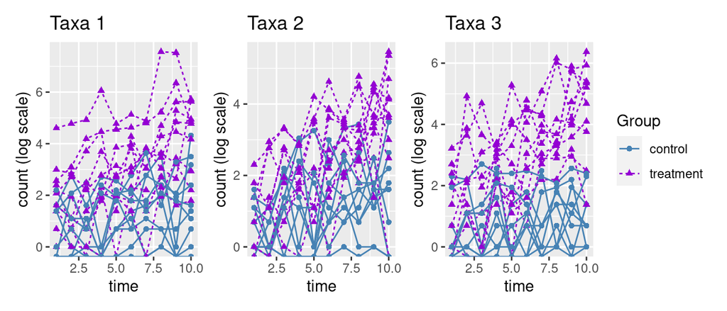

Some simulated taxa profiles with time, group and group * time effects and 0.2 dispersion

```r
fit_list <- lapply(2:10,
                   function(d) {
                     fit.rr <-
                     glmmTMB(count ~ group*time+ rr(-1 + taxa|subject,d = d),
                                              data = training, family = nbinom2)
                       })

# compare fits via AIC
aic_vec <- sapply(fit_list, AIC)
aic_vec - min(aic_vec, na.rm = TRUE)
```

[output not shown]

# What I am studying: The impact of covariates on the data

What am L doing with ny model, what does my model be used for what will my model be used for. Speak to Dr Stearn. What would my model be used for, what would my model It is What would the model be useed for?

## What I will be doing

1. Fittingthe model itself.
2. I will be doing goodness of fit test
3. I will be shrinking the estimates and comparring the results with NZZBIM and other existing models
4. I will be doing model inferenceings
5. Find a way to do ordination plots and how to interprete it

# What I will need help for

1. Get data

## Time Line

1. This Term, Finish the power project and get it published and present it int a conference of 2 January , Febaury, March April, May June… Set specific goal
2. Next term complement the longitudinal project and fininihs it. Set specific goals.

I will be doing the that have been used in the analysis of microbiome data

1. The gllvm packge What are some of the advanges of the pack

The algorithm used in the model-fitting is fast and can handle much larger datasets ()MLE and avoids MC estimations. Thus it can handle large datasets relatively quicker than other existing packages. Secondly, it uses a maximum likelihood framework, which allows the use of likelihood-based tools for inferencing. A limitation however, of gllvm is that it does assume observations are independent and thus does not account for correlation. Also, it does not include random slopes for predictors, which could enhance the account for the interspective variations in the responses.

The gllvm package implements generalised linear latetnt variable for modelling microbiome gene data. The latent variable component is used to capture the covariation between species not accounted for by the predictors. A key advantage of this package is that is computational speed and its ability to handle large datasets.

gllvm has been recently been update with the capacity to include random slope component to the GLLVM models, which was not there previously. to capture variation in environmental response not captured by the trait model.” (Niku et al., 2019, p. 2180)

The packege has various functionality for statistical inference, model visualization and model selection (AICs). Give examples The used what is known as maximises the log-likelihood using the Gaussian variational approximations (VA, Hui et al., 2017) for overdispersed counts, binary and ordinal responses, or using Laplace approximations (LA, Niku et al., 2017) for other exponential family distributions when a fully closed form variational” (Niku et al., 2019, p. 2175). It has functionality for modeling poision, NZ and ZIP for count data. It uses automatic differentiation in C++ and has carfully chosen startign values

The corresponding ordination plot then provides a graphical representation of which sites are similar in terms of their species composition.” (Niku et al., 2019, p. 2176) # Special features of microbiome data that makes it difficult to analyse Microbiome data have several features. Microbiome count data, i.e., OTU counts, taxa abundance, are naturally constrained, high dimensional, sparse with containing a large proportion of zero counts in the OTU(Taxa) table, complex covariance and correlation structures among different OTUs(taxa), and over-dispersed with large within-group heterogeneities.

## what problems do each of them cause and how have they been addressed in the literature.

1. Overview and background of the project
2. What are the research questions are you addressing?
3. What are the challenges in addressing these questions?
4. What have people done about the problem already. What methods exist. How are these methods being applied both within the field of microbiome studies and as well as in other related fields. describe these methods.
5. What packages exist. How do the packages work. What are the limitations and advantages of each of those packages. How is yours different?
6. How would l address that challenges I have mentioned
7. What is my contribution to the research area. What make your method different. What are some of the existing packages for the things you are doing. What are some of the loop holes in the current literature. How do you addres them and what is unquie about your method.
8. What have you already done about the problem: simulation studies

# Research Plan

## The procedure

Write a clear distribution of the procedure.

## Chapter 1 Power analysis

### Overview and background

#### Factors that influences power of a study

Power is a function of effect sizes, alpha, and sample sizes. Power,effect sizes, alpha, and sample sizes are all related. Each is dependent on the other three (Cohen 1988). (page 14). For example, sample sizes can be calculated given effect size, power, and alpha level, and effect sizes can be calculated given power, sample size, and alpha level. Other factors affecting power are the experimental design, number of groups, statistical procedure and model, correlation between time points, response variable, and missing data (Xia, ..). For example: …

### Research questions

1. investigate the relationships among power, effect sizes and abundances with the aim of understanding the mechanisms behind these relationships.
2. investigate the number of sample sizes required to detect a given power and a given effect size.

### Literature review

1. Other areas the methods are being applied

A reparameterized Dirichlet multinomial model was developed by La Rosa et al. to test the hypothesis of mean abundances as well as scales (variance comparison/dispersion) between groups (La Rosa et al. 2012). This paradigm is implemented in the HMP Package in R. The package’s capability includes the capacity to carry out parameter estimates, multiple hypothesis testing, and power and sample size calculations. In this package, the effect size is determined via a modified Cramer’s criterion, which is a measure of the distance between the vector mean abundances between groups. The modified Cramer’s criterion has the following definition and yields results between [0,1]. A criteria value of zero denotes no difference between the groups under study, whereas a value of one denotes the greatest difference possible.

La Rosa et al. (2012) demonstrated, using simulation studies, that power is influenced by effect size and sample size, overdispersion, and, in some cases, sequencing depth. According to the studies, increasing the effect size and sample size increased power while increasing overdispersion decreased power. When effect size, overdispersion, and sample size are held constant in some of the examples in the studies, the number of reads has a positive effect on power. Kristin et al. (2015) used the HMP package on a different dataset and reached the same conclusions as La Rosa et al. (2012) regarding the relationships between power, effect size, overdispersion.

Kelly … performed power analysis and sample size calculation for PERMANOVA. In his paper effect size was defined by a parameter $\omega^2$ defined by …. $\omega^2$ is similar to the coefficient of determination $R^2$ in ANOVA. The $R^2$ is anova is dependent on the sample size and is therefore not a good estimate of the general population. This problem is solved by $\omega^2$ in that $\omega^2$ accounts for the mean-squared error of observed samples. Power in this studies was defined by the proportions of p-values from the simulated matrices less than the significant level. What statisfical method of hypothesis testing did they use They used what is called the distance-based multivariate analysis of variance for the hypothesis testing.

Distance-based multivariate analysis of variance therefore provides a non-parametric test of the null hypothesis of no differences in overall bacterial compositions among the a exposure groups.

They showed that power increases with increase in the number of samples per groups, which is expected

micropower computes the effect sizes and power calculation of a PERMANOVA studies. What they do is theat they do certain datasets to estimate the population parameters which they used to conduct thier simulation studies and then conduct power analyis on it.

we sought to define the range of these parameters observed in biological data. The Human Microbiome Project (HMP) dataset provides extensive 16S rRNA marker gene data from the human microbiome sampled at multiple body sites. As such, it is a resource from which population parameters (i.e. mean pairwise distance and distance standard deviation) can be drawn to specify simulated distance matrices.

The power of PERMANOVA depends on the sample sizes, the alternative hypothesis that can be specified by different population-level microbial compositions among a groups, and their variances.

(By convention, negative x2 values are treated as 0.) The scale of effects was different for the different distance metrics, but the rank order of effect sizes observed for different interventions was largely consistent.

We have demonstrated that the choice of distance metric may significantly influence the observed effect, and that the withingroup variance depends upon both the chosen distance metric and planned sampling site.

La Rosa et al. (2012) recently proposed another method for the detection of significant between-group differences in microbiome data based on parametric testing of overdispersed taxonomic data against the Dirichlet-multinomial (DM) distribution and implemented their method as an R package, HMP. HMP allows the estimation of power or necessary sample size for studies with microbiome outcome measures, based on the framework of hypothesis testing at the level of the OTU vectors themselves. However, the DM distribution must be specified, via parameters representing the degree of overdispersion, the number of taxa and the expected composition of taxonomic frequencies in both groups, in order to detect a significant difference.

### limitation

One limitation of our method and that of La Rosa et al. (2012) is that these methods can only perform power calculation for categorical covariates. For a continuous covariate such as age or body mass index, one can test its association with microbiome composition using kernel-based regression (Chen and Li, 2013), where the kernel matrix can be defined based on the pairwise distances

But our method can allows for both categorical and continuous covariates which can be specified in DESEQ2 as $~condition + condition:age$, were for instance one is interested in understanding how changes the individual groups is influenced by changes in age (https://support.bioconductor.org/p/126713/). Understand this deeply. *The interpretation of the LFC is the log of the fold change in expression for one unit of the variable.* The interpretation boils done to how you would interpretes continouus variables in a linear model. To understand it, what you could go is to do a simulation studies to see what the foldchanges would be.. Do you gert a coeffict estimates for condition:age as well?

The 2 methods only provide a pointwise estimate for the effect sizes. However, knowing the distribuitons of the effect sizes is useful.

#### Our Procudure

We might need to specify a few different distrbutions based on what we have seen that the distributions of controls for different datasets look like ti decide whcih of these distributions best fit a given dataset. We get the dataset, we fit the dataset

You need to find out the effects reported in the datasets you are using and compare them to the effect you are getting.

### The delta method

Write up on the delta method. The delta method will be used to estimate the standardised error for the control abundance and the effect sizes defined

Let $C$ and $T$ denote the control and treatment groups respectively. The standard error of fold changes is define be estimated as follows:

$$\textbf{var}[\log_2\left(\frac{T}{C}\right)] =
\textbf{var}[\log_2(T)] + \textbf{var}[\log_2(C)]$$
From Taylor series expansion $\textbf{var}[f(X)] = \textbf{var}[f(\mu_X + X - \mu_X)] \approx \textbf{var}[f(\mu_X) + f'(\mu_X)(X - \mu_X) + \frac{f''(\mu_X)(X - \mu_X)]}{2} + ..= f'(\mathbb{E}[X])\textbf{var}[X]^2$ ,

$$\begin{aligned}
for f(X) = \log_2(X), f' &= \frac{1}{x\ln 2}\\
\textbf{var}[\log_2\left(\frac{T}{C}\right)] &=
\textbf{var}[\log_2(T)] + \textbf{var}[\log_2(C)]\\
&\approx \frac{1}{T\ln 2}\textbf{var}[T] + \frac{1}{C\ln
2}\textbf{var}[C]\\
\mathbb{SE}[\log_2\left(\frac{T}{C}\right)] &= \sqrt{\frac{1}{T\ln
2}\textbf{var}[T] + \frac{1}{C\ln 2}\textbf{var}[C]}
\end{aligned}$$

#### Difference between what we seek to do and HMP

#### The limitations of the multinomial modeling in modeling microbiome data

The multinomial model assumes that the true frequency of each taxon is the same for all samples. This then implies that as the number of reads within each sample increases, taxa frequencies in all samples converge to the same value. Example 40% taxa A, 20% taxa B, etc.. for all samples. When there is overdispersion, that convergence does not work Thus it is incapable of handling overdispersion in the data and will result in type 1 error if it is used for hypothesis testing.

#### The Dirichlet-multinomial distribution

1. It has 2 sets of parameters $pi$;a vector of relative abundances of taxa j the proportion of and $\theta$
2. How does it do the modelling
3. How is the parameter estimation done?

So estimation of the model parameters is done by the method of moment estimates of mle. Testing pf the hypothesis is done by the generalised wald test.

*It was proposed to test the null hypothesis using the generalized Wald test of Koehler and Wilson (1986) and La Rosa et al. (2012).*

### Challenges

### Current work

#### Simulations studies

### References

## Chapter 2 Longitudinal studies

THe main idea is Where are some of thte methods being used in longitudianl data analysis? Hwo are these methods being used? What packages are there, what kinds of reseacrh questions does longituidanal data analysis answer? WHat can be done. What are some of the challenges. Get the general picture

key scientific questions investigators are addressing with longitudinal microbiome analyses.

The questions that longitudinal microbiome studies often address in the literature are as follows. MOdelling the … These mgroupss of methods have been used often in the literature

#### gllvm

“Jenni Niku” ([Niku et al., 2017, p. 498] extended the generalized linear model to include a latent variable to account for covariation between species and correlation and applied it to the model metagenomic dataset. This generalized linear latent variable model is implemented in the gllvm package in R and can be used for fitting longitudinal data.

The algorithm used in the model-fitting is fast and can handle much larger datasets ()MLE and avoids MC estimations. Thus it can handle large datasets relatively quicker than other existing packages. Secondly, it uses a maximum likelihood framework, which allows the use of likelihood-based tools for inferencing. A limitation however, of gllvm is that it does assume observations are independent and thus does not account for correlation. Also, it does not include random slopes for predictors, which could enhance the account for the interspective variations in the responses.

### Research Questions

The goal of this project is to 1. model the relationship between otu counts and covariates (examples; time, age, gender and groups) while capturing the correlation structure within and between individual taxa and temporal patterns of taxa over time. 2. find taxa with differential abundances over time between groups. We consider a simple of where there are only 2 groups but the model can be extended to more than two groups. Model how microbiome abundance changes over time between groups.

## Chapter 3 Handling compositionality in microbiome data

One has said that you can avoid compositionality by sequesnsiyng using…. However, itis still a problem

## What are the cahllenges of each research question in each chapter

1. Understand false discovery rates and its relations to effect sizes in general. Understand what the literature says concerning false discovery rate and effect sizes

# Literature Review

# Research Plan

It was proposed to test the null hypothesis using the generalized Wald test of Koehler and Wilson (1986) and La Rosa et al. (2012).

Packages used for differential gene expressions

1. Deseq2, edgeR, limma,

## Cpater for will be to handle compositionallity